# plotly_challege_Ibrayeva

## Assignment 7: plotly Challenge

> *Sofiya Ibrayeva*

> **03.04.2024**

```python
import pandas as pd
import numpy as np
import matplotlib.pyplot as plt
%matplotlib inline
import plotly.express as px
```

# Group 1

# explain why we need to remove certain columns and replace certain values

```python
pokemon = pd.read_csv('pokedex.csv', na_values = '?')
pokemon.head()
```

|  | Nat | Pokemon | HP | Atk | Def | SpA | SpD | Spe | Total | Type I | Type II | Ability I | Ability II | Hidden Ability | EV Worth | Gender | Egg Group I | Egg Group II | Catch | Evolve |
| --- | --- | --- | --- | --- | --- | --- | --- | --- | --- | --- | --- | --- | --- | --- | --- | --- | --- | --- | --- | --- |
| 0 | 1 | Bulbasaur | 45.0 | 49.0 | 49.0 | 65.0 | 65.0 | 45.0 | 318.0 | Grass | Poison | Overgrow | NaN | Chlorophyll | 1 SpA | M (87.5%) | Monster | Grass | 45.0 | NaN |
| 1 | 2 | Ivysaur | 60.0 | 62.0 | 63.0 | 80.0 | 80.0 | 60.0 | 405.0 | Grass | Poison | Overgrow | NaN | Chlorophyll | 1 SpA/1 SpD | M (87.5%) | Monster | Grass | 45.0 | Lv. 16 |
| 2 | 3 | Venusaur | 80.0 | 82.0 | 83.0 | 100.0 | 100.0 | 80.0 | 525.0 | Grass | Poison | Overgrow | NaN | Chlorophyll | 2 SpA/1 SpD | M (87.5%) | Monster | Grass | 45.0 | Lv. 32 |
| 3 | 4 | Charmander | 39.0 | 52.0 | 43.0 | 60.0 | 50.0 | 65.0 | 309.0 | Fire | NaN | Blaze | NaN | Solar Power | 1 Spe | M (87.5%) | Monster | Dragon | 45.0 | NaN |
| 4 | 5 | Charmeleon | 58.0 | 64.0 | 58.0 | 80.0 | 65.0 | 80.0 | 405.0 | Fire | NaN | Blaze | NaN | Solar Power | 1 SpA/1 Spe | M (87.5%) | Monster | Dragon | 45.0 | Lv. 16 |

```python
#removing columns
pokemon_tidy = pokemon.drop(columns = ['Type II', \
                                       'Ability II', \
                                       'Hidden Ability', \
                                       'EV Worth', \
                                       'Gender', \
                                       'Egg Group I', \
                                       'Egg Group II', \
                                       'Evolve']).dropna()
pokemon_tidy
```

|  | Nat | Pokemon | HP | Atk | Def | SpA | SpD | Spe | Total | Type I | Ability I | Catch |
| --- | --- | --- | --- | --- | --- | --- | --- | --- | --- | --- | --- | --- |
| 0 | 1 | Bulbasaur | 45.0 | 49.0 | 49.0 | 65.0 | 65.0 | 45.0 | 318.0 | Grass | Overgrow | 45.0 |
| 1 | 2 | Ivysaur | 60.0 | 62.0 | 63.0 | 80.0 | 80.0 | 60.0 | 405.0 | Grass | Overgrow | 45.0 |
| 2 | 3 | Venusaur | 80.0 | 82.0 | 83.0 | 100.0 | 100.0 | 80.0 | 525.0 | Grass | Overgrow | 45.0 |
| 3 | 4 | Charmander | 39.0 | 52.0 | 43.0 | 60.0 | 50.0 | 65.0 | 309.0 | Fire | Blaze | 45.0 |
| 4 | 5 | Charmeleon | 58.0 | 64.0 | 58.0 | 80.0 | 65.0 | 80.0 | 405.0 | Fire | Blaze | 45.0 |
| ... | ... | ... | ... | ... | ... | ... | ... | ... | ... | ... | ... | ... |
| 1012 | 1,013 | Sinistcha | 71.0 | 60.0 | 106.0 | 121.0 | 80.0 | 70.0 | 508.0 | Grass | Hospitality | 60.0 |
| 1013 | 1,014 | Okidogi | 88.0 | 128.0 | 115.0 | 58.0 | 86.0 | 80.0 | 555.0 | Poison | Toxic Chain | 3.0 |
| 1014 | 1,015 | Munkidori | 88.0 | 75.0 | 66.0 | 130.0 | 90.0 | 106.0 | 555.0 | Poison | Toxic Chain | 3.0 |
| 1015 | 1,016 | Fezandipiti | 88.0 | 91.0 | 82.0 | 70.0 | 125.0 | 99.0 | 555.0 | Poison | Toxic Chain | 3.0 |
| 1016 | 1,017 | Ogerpon (TM) | 80.0 | 120.0 | 84.0 | 60.0 | 96.0 | 110.0 | 550.0 | Grass | Defiant | 5.0 |

1010 rows × 12 columns

```python
fig=px.scatter(pokemon_tidy, x = 'Catch', y='Total',
               color = 'Type I',
               title = 'Pokemon Stats Organized by Type')
fig.show()
```

[interactive chart not shown]

```python
pokemon_tidy.fillna(0)
pokemon_tidy
```

|  | Nat | Pokemon | HP | Atk | Def | SpA | SpD | Spe | Total | Type I | Ability I | Catch |
| --- | --- | --- | --- | --- | --- | --- | --- | --- | --- | --- | --- | --- |
| 0 | 1 | Bulbasaur | 45.0 | 49.0 | 49.0 | 65.0 | 65.0 | 45.0 | 318.0 | Grass | Overgrow | 45.0 |
| 1 | 2 | Ivysaur | 60.0 | 62.0 | 63.0 | 80.0 | 80.0 | 60.0 | 405.0 | Grass | Overgrow | 45.0 |
| 2 | 3 | Venusaur | 80.0 | 82.0 | 83.0 | 100.0 | 100.0 | 80.0 | 525.0 | Grass | Overgrow | 45.0 |
| 3 | 4 | Charmander | 39.0 | 52.0 | 43.0 | 60.0 | 50.0 | 65.0 | 309.0 | Fire | Blaze | 45.0 |
| 4 | 5 | Charmeleon | 58.0 | 64.0 | 58.0 | 80.0 | 65.0 | 80.0 | 405.0 | Fire | Blaze | 45.0 |
| ... | ... | ... | ... | ... | ... | ... | ... | ... | ... | ... | ... | ... |
| 1012 | 1,013 | Sinistcha | 71.0 | 60.0 | 106.0 | 121.0 | 80.0 | 70.0 | 508.0 | Grass | Hospitality | 60.0 |
| 1013 | 1,014 | Okidogi | 88.0 | 128.0 | 115.0 | 58.0 | 86.0 | 80.0 | 555.0 | Poison | Toxic Chain | 3.0 |
| 1014 | 1,015 | Munkidori | 88.0 | 75.0 | 66.0 | 130.0 | 90.0 | 106.0 | 555.0 | Poison | Toxic Chain | 3.0 |
| 1015 | 1,016 | Fezandipiti | 88.0 | 91.0 | 82.0 | 70.0 | 125.0 | 99.0 | 555.0 | Poison | Toxic Chain | 3.0 |
| 1016 | 1,017 | Ogerpon (TM) | 80.0 | 120.0 | 84.0 | 60.0 | 96.0 | 110.0 | 550.0 | Grass | Defiant | 5.0 |

1010 rows × 12 columns

```python
fig = px.scatter(pokemon_tidy, x = 'Catch', y = 'Total',
                 color = 'Type I',
                 size = 'Catch',
                 title = 'Pokemon Organized by Catch Rate and Stat Totals',
                 width = 1000, height = 750,
                 hover_name = 'Pokemon',
                 color_discrete_map = {'Grass': 'lightgreen',
                                      'Ghost': 'lightgrey',
                                      'Dark': 'navy',
                                      'Dragon': 'mediumpurple',
                                      'Fighting': 'firebrick',
                                      'Electric': 'gold',
                                      'Water': 'aqua',
                                      'Poison': 'darkviolet',
                                      'Bug': 'forestgreen',
                                      'Ground': 'peru',
                                      'Normal': 'dodgerblue'})
fig.show()
```

[interactive chart not shown]

# describe how else you could clean up or enhance the appearance of the graph

> below is the modificated graph where i showed only top 5 types of pokemons and completely removed the other kinds. I also removed the gridlines, changed the bacjground to white and moved the title to the center . If i were to explore this graph further, i would play arounf with the grouping of elements, as well as the size of dots

```python
# Filtering the data to include only the top 5 stats in the plot

# calculating the total catch for each type by using a groupby function
type_catch_totals = pokemon_tidy.groupby('Type I')['Catch'].sum().reset_index()

# Step 2: Sort types based on total catch and select top 5
top_5_types = type_catch_totals.nlargest(5, 'Catch')['Type I']

# Step 3: Filter data to include only the top 5 types
filtered_data = pokemon_tidy[pokemon_tidy['Type I'].isin(top_5_types)]

# Create the scatter plot
fig = px.scatter(filtered_data, x='Catch', y='Total',
                 color='Type I', size='Catch',
                 title='Top 5 Pokemon Types by Catch Rate and Stat Totals',
                 width=1000, height=750,
                 hover_name='Pokemon',
                 color_discrete_map={'Grass': 'lightgreen',
                                     'Electric': 'gold',
                                     'Water': 'aqua',
                                     'Bug': 'forestgreen',
                                     'Normal': 'dodgerblue'})

# Removing the gridlines and setting the backgroung color to white
fig.update_layout(
    xaxis=dict(showgrid=False),
    yaxis=dict(showgrid=False),
    plot_bgcolor='white',
    title_x=0.5)

fig.show()
```

[interactive chart not shown]

# Group 2

```python
wq = pd.read_csv('wq.csv')
wq.head()
```

|  | Site_Id | Read_Date | Dissolved Oxygen (mg/L) | pH (standard units) | Secchi Depth (m) | Water Depth (m) | Water Temp (?C) | Air Temp (F) | Time (24:00) | AirTemp (C) | Year |
| --- | --- | --- | --- | --- | --- | --- | --- | --- | --- | --- | --- |
| 0 | A | 1/10/2013 | 6.9 | 6.5 | 0.8 | 0.9 | 8.0 | 48 | 00:00 | 8.888889 | 2013 |
| 1 | A | 1/11/2012 | 8.2 | 6.5 | 0.9 | 0.9 | 12.0 | 53 | 00:00 | 11.666667 | 2012 |
| 2 | A | 1/14/2014 | 6.8 | 6.5 | 0.5 | 0.5 | 11.0 | 53 | 10:20 | 11.666667 | 2014 |
| 3 | A | 10/13/2011 | 4.0 | 6.5 | 0.7 | 0.8 | 22.0 | 75 | 00:00 | 23.888889 | 2011 |
| 4 | A | 10/13/2015 | 6.7 | 7.0 | 0.4 | 0.4 | 15.0 | 52 | 10:35 | 11.111111 | 2015 |

```python
fig = px.histogram(wq, x='Site_Id',\
                  histfunc = 'count',\
                 color = 'Site_Id',\
                 title = 'Count of readings from each site')
fig.update_layout(showlegend=False) # removing the legend from the plot
fig.show()
```

[interactive chart not shown]

```python
fig = px.histogram(wq, x= 'Year', y= 'Dissolved Oxygen (mg/L)',\
                   color ='Site_Id',
                   barmode='group',
                   histfunc='avg',
                   text_auto = True,
                   height = 500,
                   title = ' Avg of Dissolved Oxygen for each site')
fig.show()
```

[interactive chart not shown]

```python
fig = px.histogram(wq, x= 'Year', y= 'Dissolved Oxygen (mg/L)',\
                   color ='Site_Id',
                   barmode='group',
                   histfunc='avg',
                   facet_col = 'Site_Id',
                   facet_col_wrap = 3,
                   text_auto = True,
                   height = 500,
                   title = ' Avg of Dissolved Oxygen by year for each site')
fig.update_layout(showlegend=False) # removing the legend from the plot
fig.show()
```

[interactive chart not shown]

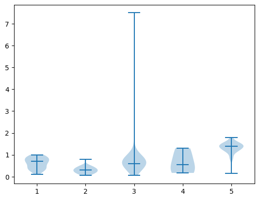

```python
# Creating a violin plot
plt.violinplot(wq['Water Depth (m)'].groupby(wq['Site_Id']).apply(list), showmeans=False, showmedians=True)
plt.show()
```

```python
wq['Water Depth (m)'].groupby(wq['Site_Id']).apply(list)
```

```
Site_Id
A      [0.9, 0.9, 0.5, 0.8, 0.4, 0.3, 0.7, 0.3, 0.5, ...
B      [0.3, 0.4, 0.05, 0.05, 0.4, 0.1, 0.2, 0.15, 0....
Bay    [0.5, 0.7, 0.6, 0.6, 0.6, 0.4, 0.8, 0.4, 0.45,...
C                                  [0.8, 0.3, 0.17, 1.3]
D      [1.4, 1.4, 1.4, 1.2, 1.5, 0.8, 1.3, 1.2, 1.2, ...
Name: Water Depth (m), dtype: object
```

```python
range(1, len(wq['Site_Id'].unique()) + 1)
```

```
range(1, 6)
```

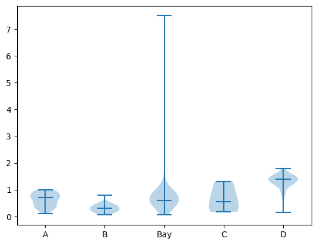

```python
# simplifying the plot
plt.violinplot(wq['Water Depth (m)'].groupby(wq['Site_Id']).apply(list), showmeans=False, showmedians=True)

plt.xticks(ticks = range(1, 6),
           labels = wq['Site_Id'].unique())
plt.show()
```

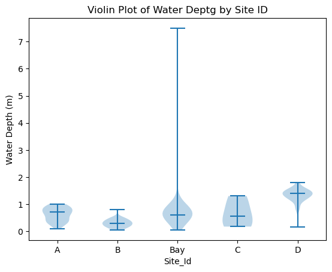

```python
plt.violinplot(wq['Water Depth (m)'].groupby(wq['Site_Id']).apply(list), showmeans=False, showmedians=True)

plt.xticks(ticks = range(1, 6),
           labels = wq['Site_Id'].unique())
plt.xlabel('Site_Id')
plt.ylabel('Water Depth (m)')
plt.title('Violin Plot of Water Deptg by Site ID')
plt.show()
```

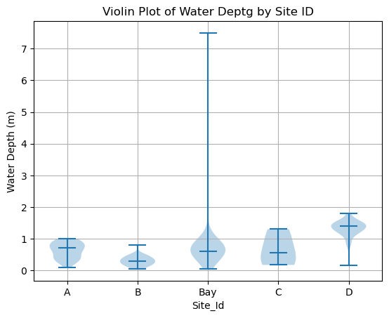

```python
plt.violinplot(wq['Water Depth (m)'].groupby(wq['Site_Id']).apply(list), showmeans=False, showmedians=True)

plt.xticks(ticks = range(1, 6),
           labels = wq['Site_Id'].unique())
plt.xlabel('Site_Id')
plt.ylabel('Water Depth (m)')
plt.title('Violin Plot of Water Deptg by Site ID')
plt.grid(True)
plt.show()
```

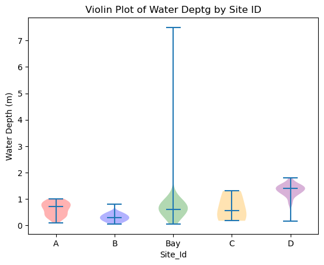

```python
violins = plt.violinplot(wq['Water Depth (m)'].groupby(wq['Site_Id']).apply(list), showmeans=False, showmedians=True)

plt.xticks(ticks = range(1, 6),
           labels = wq['Site_Id'].unique())
plt.xlabel('Site_Id')
plt.ylabel('Water Depth (m)')
plt.title('Violin Plot of Water Deptg by Site ID')
plt.grid(False)
colors = ['red', 'blue', 'green', 'orange', 'purple']
for color, violin in zip(colors, violins['bodies']):
     violin.set_facecolor(color)
plt.show()
```

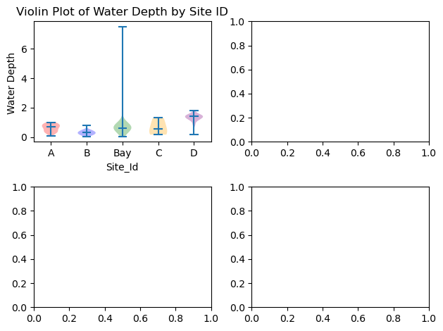

```python
fig, axs = plt.subplots(2, 2)

violins = axs[0,0].violinplot(wq['Water Depth (m)'].groupby(wq['Site_Id']).apply(list), showmeans = False, showmedians = True)
axs[0,0].set_xticks(ticks = range(1, 6),\
           labels = wq['Site_Id'].unique())

colors = ['red', 'blue', 'green', 'orange', 'purple']

for color, violin in zip(colors, violins['bodies']):
    violin.set_facecolor(color)

axs[0,0].set_xlabel('Site_Id')
axs[0,0].set_ylabel('Water Depth ')
axs[0,0].set_title('Violin Plot of Water Depth by Site ID')

axs[0,0].grid(False)

plt.tight_layout()
plt.show()
```

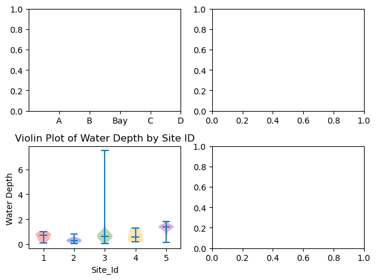

```python
#Create another violin plot on the first column, second row
fig, axs = plt.subplots(2, 2)

violins = axs[1,0].violinplot(wq['Water Depth (m)'].groupby(wq['Site_Id']).apply(list), showmeans = False, showmedians = True)
axs[0,0].set_xticks(ticks = range(1, 6),\
           labels = wq['Site_Id'].unique())

colors = ['red', 'blue', 'green', 'orange', 'purple']

for color, violin in zip(colors, violins['bodies']):
    violin.set_facecolor(color)

axs[1,0].set_xlabel('Site_Id')
axs[1,0].set_ylabel('Water Depth ')
axs[1,0].set_title('Violin Plot of Water Depth by Site ID')

axs[1,0].grid(False)

plt.tight_layout()
plt.show()
```

# Group 3

```python
jobs = pd.read_csv('jobs_in_data.csv')
jobs.head()
```

|  | work_year | job_title | job_category | salary_currency | salary | salary_in_usd | employee_residence | experience_level | employment_type | work_setting | company_location | company_size |
| --- | --- | --- | --- | --- | --- | --- | --- | --- | --- | --- | --- | --- |
| 0 | 2023 | Data DevOps Engineer | Data Engineering | EUR | 88000 | 95012 | Germany | Mid-level | Full-time | Hybrid | Germany | L |
| 1 | 2023 | Data Architect | Data Architecture and Modeling | USD | 186000 | 186000 | United States | Senior | Full-time | In-person | United States | M |
| 2 | 2023 | Data Architect | Data Architecture and Modeling | USD | 81800 | 81800 | United States | Senior | Full-time | In-person | United States | M |
| 3 | 2023 | Data Scientist | Data Science and Research | USD | 212000 | 212000 | United States | Senior | Full-time | In-person | United States | M |
| 4 | 2023 | Data Scientist | Data Science and Research | USD | 93300 | 93300 | United States | Senior | Full-time | In-person | United States | M |

```python
jobs['experience_level'].unique()
```

```
array(['Mid-level', 'Senior', 'Executive', 'Entry-level'], dtype=object)
```

```python
jobs['salary'].value_counts(normalize=True)
```

```
salary
150000    0.022662
100000    0.021700
130000    0.020738
160000    0.019776
120000    0.018386
            ...
194100    0.000107
152300    0.000107
144700    0.000107
177200    0.000107
412000    0.000107
Name: proportion, Length: 1507, dtype: float64
```

```python
fig= px.histogram(jobs, x='salary_in_usd', nbins=30, title='salary Distribution')
fig.show()
```

[interactive chart not shown]

```python
fig = px.box(jobs, x='experience_level', y='salary_in_usd',\
title='Salary Distribution by Experience Level',\
labels={'salary_in_usd': 'Salary in USD', 'experience_level': 'Experience Level'},\
category_orders={"experience_level": ["Entry-level", "Mid-level", "Senior", "Executive"]})

fig.show()
```

[interactive chart not shown]

```python
fig_dict=fig.to_dict()
import plotly.io as pio
pio.show(fig_dict)
```

[interactive chart not shown]

```python
fig_json=fig.to_json()
print(fig_json[:500])
```

```
{"data":[{"alignmentgroup":"True","hovertemplate":"Experience Level=%{x}\u003cbr\u003eSalary in USD=%{y}\u003cextra\u003e\u003c\u002fextra\u003e","legendgroup":"","marker":{"color":"#636efa"},"name":"","notched":false,"offsetgroup":"","orientation":"v","showlegend":false,"x":["Mid-level","Senior","S…
```

```python
fig_from_json=pio.from_json(fig_json)
fig_from_json.show()
```

[interactive chart not shown]

```python
fig = px.box(jobs, x='experience_level', y='salary_in_usd',\
             color='experience_level',
             title='Salary Distribution by Experience Level',\
             labels={'salary_in_usd': 'Salary in USD', 'experience_level': 'Experience Level'},\
             category_orders={"experience_level": ["Entry-level", "Mid-level", "Senior", "Executive"]})

fig.show()
```

[interactive chart not shown]

```python
fig = px.box(jobs, x='experience_level', y='salary_in_usd',\
             color='experience_level',
             color_discrete_sequence = px.colors.sequential.Sunset,
             title='Salary Distribution by Experience Level',\
             labels={'salary_in_usd': 'Salary in USD', 'experience_level': 'Experience Level'},\
             category_orders={"experience_level": ["Entry-level", "Mid-level", "Senior", "Executive"]})

fig.show()
```

[interactive chart not shown]

```python
fig=px.box(jobs, x='job_category', y ='salary_in_usd',
           title = 'Salary Distribution by Job Categoty',
           color= 'job_category',
           labels={'salary_in_usd': 'Salary in USD', 'job_category':'Job Category'})
fig.update_layout(
    title_x=0.5,  # Center the title
    showlegend=False)

fig.show()
```

[interactive chart not shown]

# provide a short discussion of the box plot graph you created in step 9 (e.g. how salary distributions are affected by factors of job categories

> In the box plot created, we are exploring the distribution of salaries across different job categories. Each box represents a specific job category, and the y-axis represents the salary in USD. The boxes represent the IQR for each job category, showing the middle 50% of salaries. The wider box basically means the greater the variability in salaries within that category. We can see that dta architecture and modeling has the biggest range amont others. However, data science and research category has the highest salaries overall. One thing we can say that the highest sallries in this boxplot are mostly outliers, because they are extending from the boxes.